# Nienadzorowana Detekcja Fraudów Bankowych

# 7 Badanie Ablacyjne: Wplyw Transformacji Yeo-Johnsona

```r
# Transformacja Yeo-Johnsona redukuje skosnosc — korzystne dla zalozen
# Mahalanobisa i LOF — ale rownoczesnie kompresuje wartosci ogonowe ku sredniej.
# W detekcji anomalii outliery w ogonach to wlasnie nasi podejrzani.
# Wynik tego badania okresla czy transformacja pomaga czy szkodzi.

rec_no_yj <- recipe(fraud_bool~., data=df_train_raw %>% select(all_of(all_features),fraud_bool)) %>%
  step_impute_median(all_numeric_predictors()) %>%
  step_dummy(all_nominal_predictors()) %>%
  step_zv(all_predictors()) %>%
  step_corr(all_numeric_predictors(), threshold=0.85) %>%
  step_normalize(all_numeric_predictors()) %>%
  prep()

train_noyj <- bake(rec_no_yj, new_data=NULL)
test_noyj  <- bake(rec_no_yj, new_data=df_test_raw)
rm(rec_no_yj); gc(verbose=FALSE)
```

```
##             used   (Mb) gc trigger   (Mb)  max used   (Mb)
## Ncells   3461566  184.9    6329714  338.1   6329714  338.1
## Vcells 268072140 2045.3  385933359 2944.5 385765082 2943.2
```

```r
shared <- intersect(setdiff(names(df_train_baked),"fraud_bool"),
                    setdiff(names(train_noyj),"fraud_bool"))

tr_yj   <- as.matrix(df_train_baked[,shared])
te_yj   <- as.matrix(df_test_baked[,shared])
tr_noyj <- as.matrix(train_noyj[,shared])
te_noyj <- as.matrix(test_noyj[,shared])

# Mahalanobis
sc_m_yj   <- as.numeric(tryCatch(mahalanobis(te_yj,   colMeans(tr_yj),   cov(tr_yj)),   error=function(e) rep(NA,nrow(te_yj))))
sc_m_noyj <- as.numeric(tryCatch(mahalanobis(te_noyj, colMeans(tr_noyj), cov(tr_noyj)), error=function(e) rep(NA,nrow(te_noyj))))

auc_m_yj   <- tryCatch(as.numeric(auc(roc(y_test,sc_m_yj,   quiet=TRUE))), error=function(e) NA)
auc_m_noyj <- tryCatch(as.numeric(auc(roc(y_test,sc_m_noyj, quiet=TRUE))), error=function(e) NA)

# LOF
set.seed(42); n_ref <- min(5000,nrow(tr_yj)); q_idx <- sample(nrow(te_yj),min(10000,nrow(te_yj)))
knn_yj   <- dbscan::kNN(x=tr_yj[sample(nrow(tr_yj),n_ref),],   query=te_yj[q_idx,],   k=20)
knn_noyj <- dbscan::kNN(x=tr_noyj[sample(nrow(tr_noyj),n_ref),], query=te_noyj[q_idx,], k=20)

auc_l_yj   <- tryCatch(as.numeric(auc(roc(y_test[q_idx],rowMeans(knn_yj$dist),   quiet=TRUE))), error=function(e) NA)
auc_l_noyj <- tryCatch(as.numeric(auc(roc(y_test[q_idx],rowMeans(knn_noyj$dist), quiet=TRUE))), error=function(e) NA)

tibble(
  Model     = c("Mahalanobis","Mahalanobis","LOF (kNN-dist)","LOF (kNN-dist)"),
  Wariant   = c("Z Yeo-Johnson","Bez YJ","Z Yeo-Johnson","Bez YJ"),
  `AUC (OOS)` = round(c(auc_m_yj,auc_m_noyj,auc_l_yj,auc_l_noyj),4),
  `Delta vs bez YJ` = round(c(auc_m_yj-auc_m_noyj, 0, auc_l_yj-auc_l_noyj, 0),4)
) %>%
  kable(caption="Badanie ablacyjne: Yeo-Johnson vs normalizacja bez transformacji (delta dodatnia = YJ pomaga)") %>%
  kable_styling(bootstrap_options=c("striped","hover","condensed"), full_width=FALSE)
```

Badanie ablacyjne: Yeo-Johnson vs normalizacja bez transformacji (delta dodatnia = YJ pomaga)

| Model | Wariant | AUC (OOS) | Delta vs bez YJ |
| --- | --- | --- | --- |
| Mahalanobis | Z Yeo-Johnson | 0.5642 | -0.0282 |
| Mahalanobis | Bez YJ | 0.5924 | 0.0000 |
| LOF (kNN-dist) | Z Yeo-Johnson | 0.5833 | -0.0321 |
| LOF (kNN-dist) | Bez YJ | 0.6154 | 0.0000 |

```r
rm(train_noyj, test_noyj, tr_yj, te_yj, tr_noyj, te_noyj, sc_m_yj, sc_m_noyj,
   knn_yj, knn_noyj, shared, n_ref, q_idx); gc(verbose=FALSE)
```

```
##             used   (Mb) gc trigger   (Mb)  max used   (Mb)
## Ncells   3462128  184.9    6329714  338.1   6329714  338.1
## Vcells 236573563 1805.0  385933359 2944.5 385765082 2943.2
```

# 8 PCA — Ocena Separowalnosci Klas

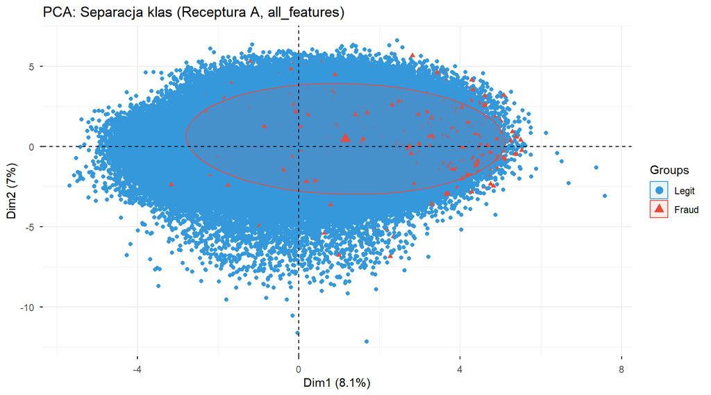

```r
pca_res <- prcomp(df_ml %>% select(-fraud_bool), scale.=TRUE)
fviz_pca_ind(pca_res, label="none", habillage=df_ml$fraud_bool,
             palette=c("#3498db","#e74c3c"), addEllipses=TRUE,
             title="PCA: Separacja klas (Receptura A, all_features)")
```

```r
rm(pca_res)
```

# 9 Model 1: Odleglosc Mahalanobisa

Odleglosc Mahalanobisa mierzy jak daleko kazda transakcja lezy od centrum rozkladu legalnych transakcji, uwzgledniajac korelacje miedzy zmiennymi. Jest jedynym modelem parametrycznym w stosie, zakladajacym wielowymiarowa normalnosc rozkładu.

Ograniczenia na tym zbiorze: - Zaklada normalnosc spelniona po transformacji YJ, ale nie idealnie - Wrazliwa na osobliwosc macierzy kowariancji rozwiazana przez `step_corr` i regularyzacje Ridge - Nie adaptuje sie do concept driftu — wzorzec normalnosci pochodzi z miesiecy 0-5

```r
mu_train <- colMeans(df_train_baked %>% select(-fraud_bool))
S_train  <- cov(df_train_baked %>% select(-fraud_bool))

# Regularyzacja Ridge: epsilon na przekatnej zapobiega osobliwosci macierzy
# wynikajacej z wysokiej korelacji cech velocity i flag brakow danych
epsilon <- 1e-6
diag(S_train) <- diag(S_train) + epsilon

score_mahala <- as.numeric(tryCatch(
  mahalanobis(df_test_baked %>% select(-fraud_bool), center=mu_train, cov=S_train),
  error = function(e) { cat("Blad Mahalanobisa:", e$message, "\n")
                        rep(NA, nrow(df_test_baked)) }
))

roc_mahala <- roc(y_test, score_mahala, quiet=TRUE)
cat("Mahalanobis (OOS) - AUC:", round(auc(roc_mahala), 4), "\n")
```

```
## Mahalanobis (OOS) - AUC: 0.5643
```

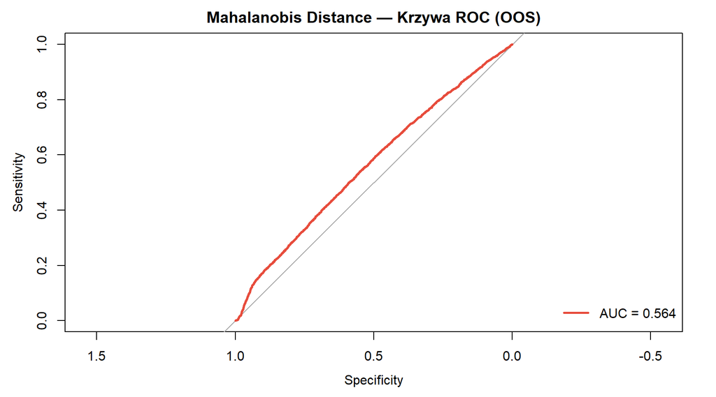

```r
plot(roc_mahala, col="#e74c3c", lwd=2.5,
     main="Mahalanobis Distance — Krzywa ROC (OOS)")
legend("bottomright", legend=paste("AUC =", round(auc(roc_mahala),3)),
       col="#e74c3c", lwd=2.5, bty="n")
```

```r
rm(mu_train, S_train, epsilon); gc(verbose=FALSE)
```

```
##             used   (Mb) gc trigger   (Mb)  max used   (Mb)
## Ncells   4525817  241.8   10666598  569.7  10666598  569.7
## Vcells 283767790 2165.0  667184043 5090.3 666983351 5088.7
```

# 10 Model 2: Isolation Forest

Isolation Forest izoluje anomalie przez losowe podzialy przestrzeni cech. Punkty anomalne sa izolowane szybciej (krotsze sciezki w drzewie) i dostaja wyzszy score.

Jest jedynym modelem w stosie strukturalnie odpornym na skosnosc rozkladow oraz na artefakt po anonimizacji danych (podzialy na pojedynczych cechach nie akumuluja efektu one-hot).

Eksperymenty wykazaly, ze iForest na surowych danych (bez YeoJohnson i normalizacji) daje AUC 0.6134, identyczny jak z normalizacja.

```r
iof_path <- "saved_models/isolation_forest_raw.rds"
dir.create("saved_models", showWarnings=FALSE)

if (file.exists(iof_path)) {
  model_iof <- readRDS(iof_path)
} else {
  set.seed(123)
  model_iof <- isolation.forest(tr_raw %>% select(-fraud_bool),
                                 ntrees=500, sample_size=128)
  saveRDS(model_iof, iof_path)
}

score_iof <- predict(model_iof, te_raw %>% select(-fraud_bool))
roc_iof   <- roc(y_test, score_iof, quiet=TRUE)
cat("Isolation Forest (surowe dane, OOS) - AUC:", round(auc(roc_iof),4), "\n")
```

```
## Isolation Forest (surowe dane, OOS) - AUC: 0.6134
```

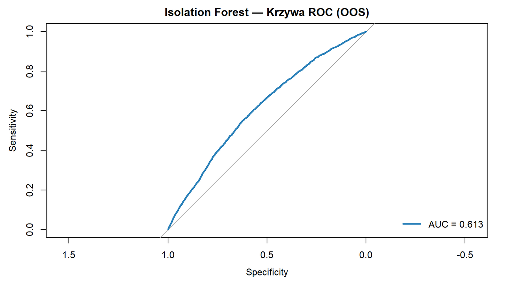

```r
plot(roc_iof, col="#2980b9", lwd=2.5,
     main="Isolation Forest — Krzywa ROC (OOS)")
legend("bottomright", legend=paste("AUC =",round(auc(roc_iof),3)),
       col="#2980b9", lwd=2.5, bty="n")
```

```r
gc(verbose=FALSE)
```

```
##             used   (Mb) gc trigger   (Mb)  max used   (Mb)
## Ncells   4525915  241.8   10666598  569.7  10666598  569.7
## Vcells 285203293 2176.0  667184043 5090.3 666983351 5088.7
```

# 11 Model 3: Local Outlier Factor (LOF)

LOF mierzy lokalna gestosc kazdej transakcji wzgledem jej sasiadow. Transakcje otoczone rzadkimi sasiadami (niska gestosc wzgledem otoczenia) dostaja wysoki score.

Analiza fairness wykazuje ze LOF z wiekiem jako cecha generuje FPR = 1.0 dla klientow 80+.Dzieje się tak ponieważ seniorzy są najmniejszą grupą w całym zbiorze ,ale odsetek anomali jest pośródn nich największy.

Klasyczny LOF nie posiada metody `predict()` i nie moze byc zastosowany na nowych danych. Aproksymacja przez srednia odleglosci kNN do referencyjnej bazy legalnych transakcji jest standardowym podejsciem produkcyjnym.

```r
set.seed(42)
# Określenie liczby obserwacji referencyjnych (tylko transakcje uczciwe)
n_ref_lof   <- min(20000, sum(df_train_baked$fraud_bool == "Legit"))

# Przygotowanie macierzy danych referencyjnych (treningowych) bez etykiety i wieku
ref_data   <- df_train_baked %>%
  filter(fraud_bool == "Legit") %>%
  select(-fraud_bool, -any_of("customer_age")) %>%
  slice_sample(n = n_ref_lof) %>%
  as.matrix()

# Przygotowanie macierzy danych testowych
test_data <- df_test_baked %>%
  select(-fraud_bool, -any_of("customer_age")) %>%
  as.matrix()

# POPRAWKA: Jawne wywołanie funkcji z pakietu dbscan, aby uniknąć konfliktów maskowania
knn_res   <- dbscan::kNN(x = ref_data, query = test_data, k = 20)
score_lof <- rowMeans(knn_res$dist)

# Obliczenie krzywej ROC
roc_lof <- roc(y_test, score_lof, quiet = TRUE)

# POPRAWKA: Bezpieczne rzutowanie na as.numeric() przy wypisywaniu wyniku
cat("LOF (kNN-dist, k=20, wiek wylaczony, OOS) - AUC:", round(as.numeric(auc(roc_lof)), 4), "\n")
```

```
## LOF (kNN-dist, k=20, wiek wylaczony, OOS) - AUC: 0.5527
```

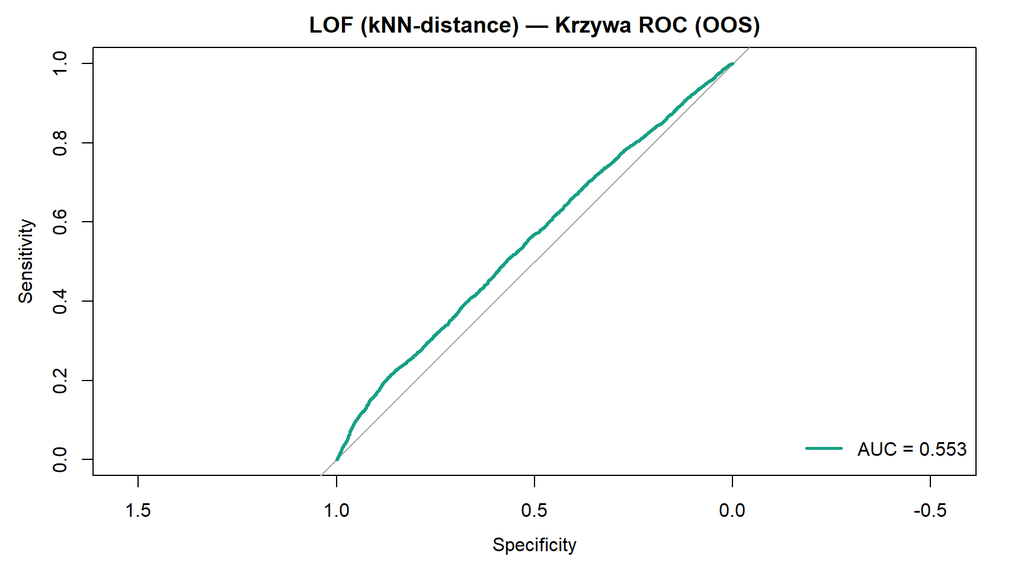

```r
# Wykres krzywej ROC
plot(roc_lof, col = "#16a085", lwd = 2.5,
     main = "LOF (kNN-distance) — Krzywa ROC (OOS)")
legend("bottomright", legend = paste("AUC =", round(as.numeric(auc(roc_lof)), 3)),
       col = "#16a085", lwd = 2.5, bty = "n")
```

```r
# Czyszczenie pamięci podręcznej
rm(ref_data, test_data, knn_res, n_ref_lof); gc(verbose = FALSE)
```

```
##             used   (Mb) gc trigger   (Mb)  max used   (Mb)
## Ncells   3187267  170.3    4678850  249.9   4678850  249.9
## Vcells 611362136 4664.4  907315071 6922.3 702116558 5356.8
```